# TP Regression lineaire

gueddou chaouki

2017 M04 9

## TP Regression lineaire

### Exercice 1

```r
x <- c(2,5,3,7)
y = 2*x+5
lm(y ~ x)
```

```
##
## Call:
## lm(formula = y ~ x)
##
## Coefficients:
## (Intercept)            x
##           5            2
```

**commentaire** aucun

```r
dframe <- data.frame(x=c(2,5,3,7) , y=c(9, 15, 11, 19))
reglin <- lm(y ~x, dframe)
```

**commentaire** aucun

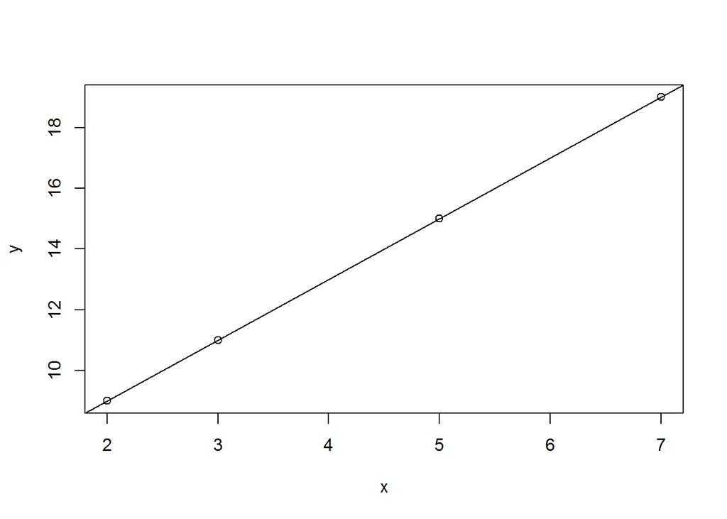

```r
plot(y ~ x, dframe)
abline(lm(y ~ x, dframe))
```

```r
xi <- c(1:12)
xi
```

```
##  [1]  1  2  3  4  5  6  7  8  9 10 11 12
```

**commentaire** aucun

```r
yi <- c(40, 42, 44, 45, 48, 50, 52, 55, 58, 63, 68, 70)
yi
```

```
##  [1] 40 42 44 45 48 50 52 55 58 63 68 70
```

**commentaire** aucun

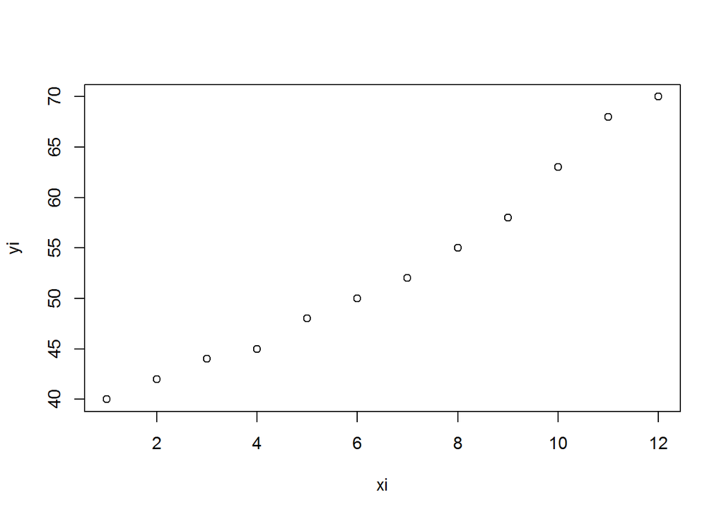

```r
plot(xi, yi)
```

**commentaire** aucun

```r
lm(yi ~ xi)
```

```
##
## Call:
## lm(formula = yi ~ xi)
##
## Coefficients:
## (Intercept)           xi
##      35.076        2.745
```

**commentaire** aucun

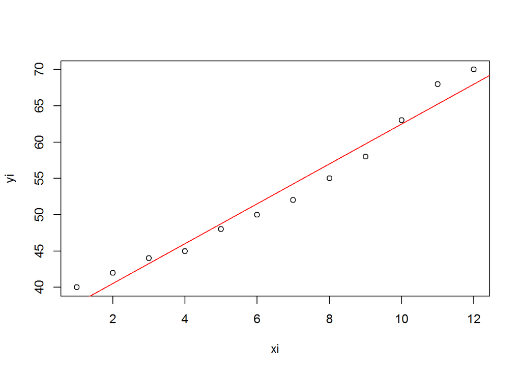

```r
plot(xi, yi)
abline(35.076,2.745,col='red')
```

**commentaire** aucun

```r
2.745 * 13 + 35.076
```

```
## [1] 70.761
```

**commentaire** aucun

```r
data.frame(xi, yi)
```

```
##    xi yi
## 1   1 40
## 2   2 42
## 3   3 44
## 4   4 45
## 5   5 48
## 6   6 50
## 7   7 52
## 8   8 55
## 9   9 58
## 10 10 63
## 11 11 68
## 12 12 70
```

```r
summary(xi)
```

```
##    Min. 1st Qu.  Median    Mean 3rd Qu.    Max.
##    1.00    3.75    6.50    6.50    9.25   12.00
```

```r
summary(yi)
```

```
##    Min. 1st Qu.  Median    Mean 3rd Qu.    Max.
##   40.00   44.75   51.00   52.92   59.25   70.00
```

### Exercice 3

**commentaire** aucun

```r
data(iris)
head(iris)
```

```
##   Sepal.Length Sepal.Width Petal.Length Petal.Width Species
## 1          5.1         3.5          1.4         0.2  setosa
## 2          4.9         3.0          1.4         0.2  setosa
## 3          4.7         3.2          1.3         0.2  setosa
## 4          4.6         3.1          1.5         0.2  setosa
## 5          5.0         3.6          1.4         0.2  setosa
## 6          5.4         3.9          1.7         0.4  setosa
```

```r
structure(iris)
```

```
##     Sepal.Length Sepal.Width Petal.Length Petal.Width    Species
## 1            5.1         3.5          1.4         0.2     setosa
## 2            4.9         3.0          1.4         0.2     setosa
## 3            4.7         3.2          1.3         0.2     setosa
## 4            4.6         3.1          1.5         0.2     setosa
## 5            5.0         3.6          1.4         0.2     setosa
## 6            5.4         3.9          1.7         0.4     setosa
## 7            4.6         3.4          1.4         0.3     setosa
## 8            5.0         3.4          1.5         0.2     setosa
## 9            4.4         2.9          1.4         0.2     setosa
## 10           4.9         3.1          1.5         0.1     setosa
## 11           5.4         3.7          1.5         0.2     setosa
## 12           4.8         3.4          1.6         0.2     setosa
## 13           4.8         3.0          1.4         0.1     setosa
## 14           4.3         3.0          1.1         0.1     setosa
```

[output cut: 136 more lines]

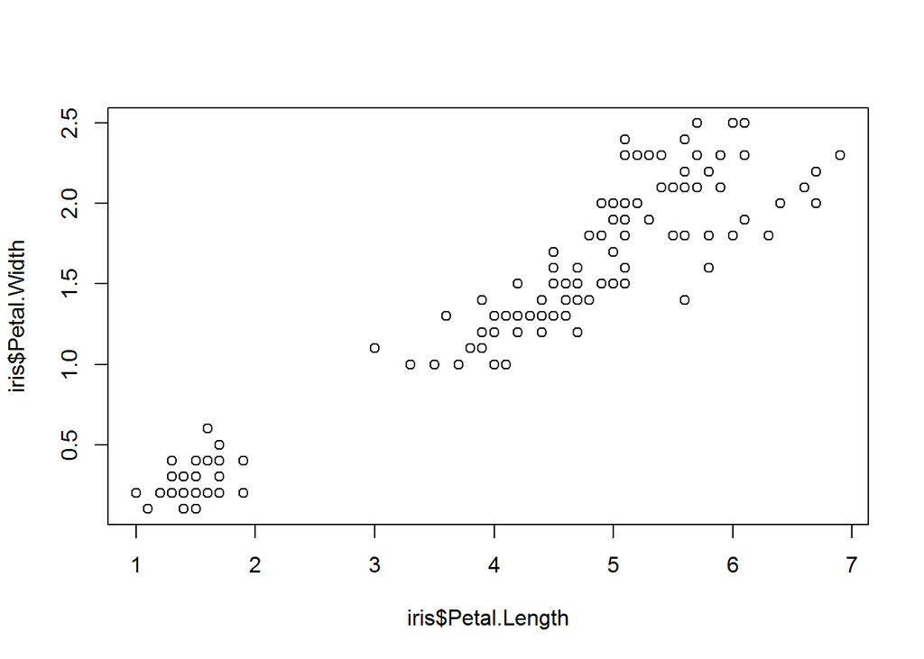

```r
require(ggplot2)
plot(iris$Petal.Length,iris$Petal.Width)
```

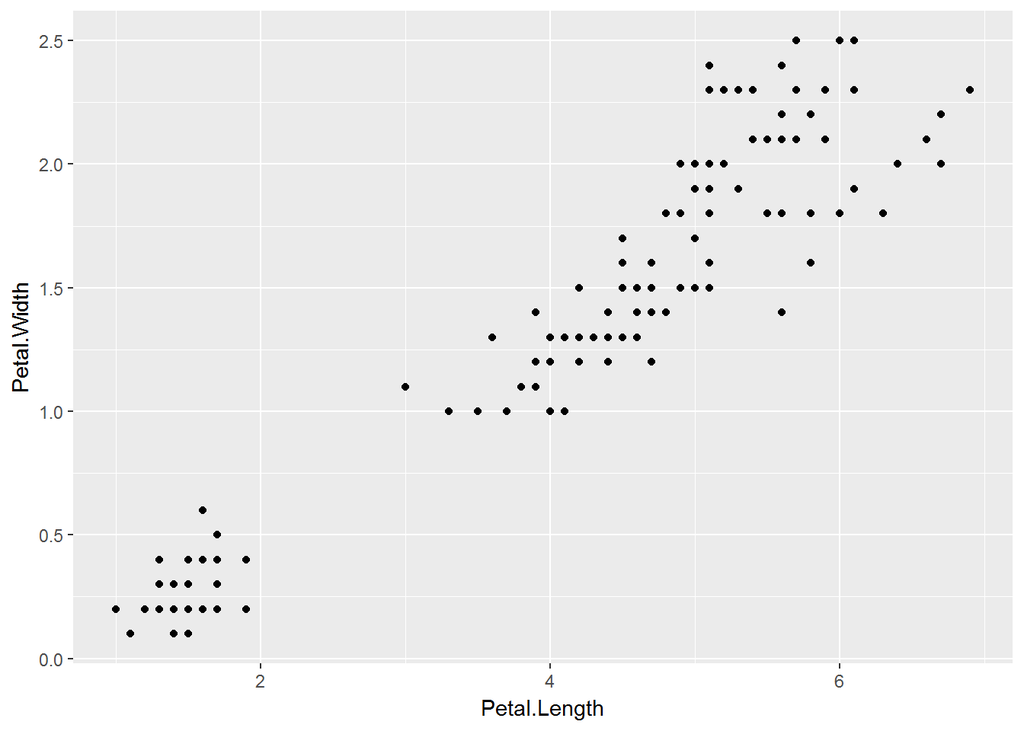

```r
qplot(Petal.Length,Petal.Width,data=iris)
```

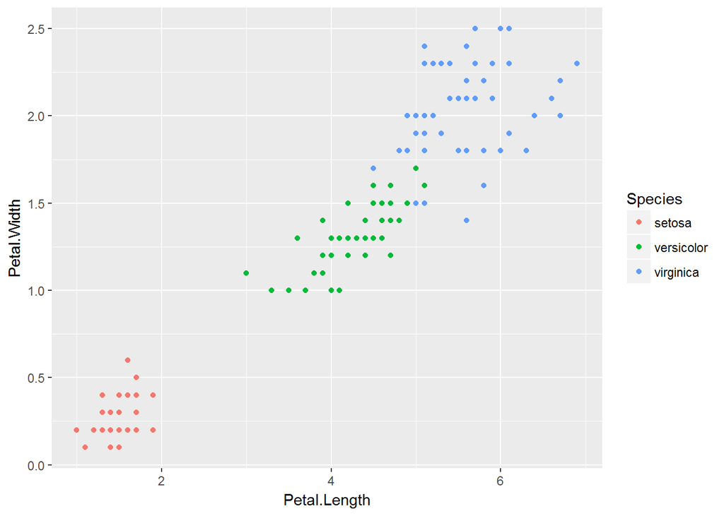

```r
qplot(Petal.Length,Petal.Width,data=iris,colour=Species)
```

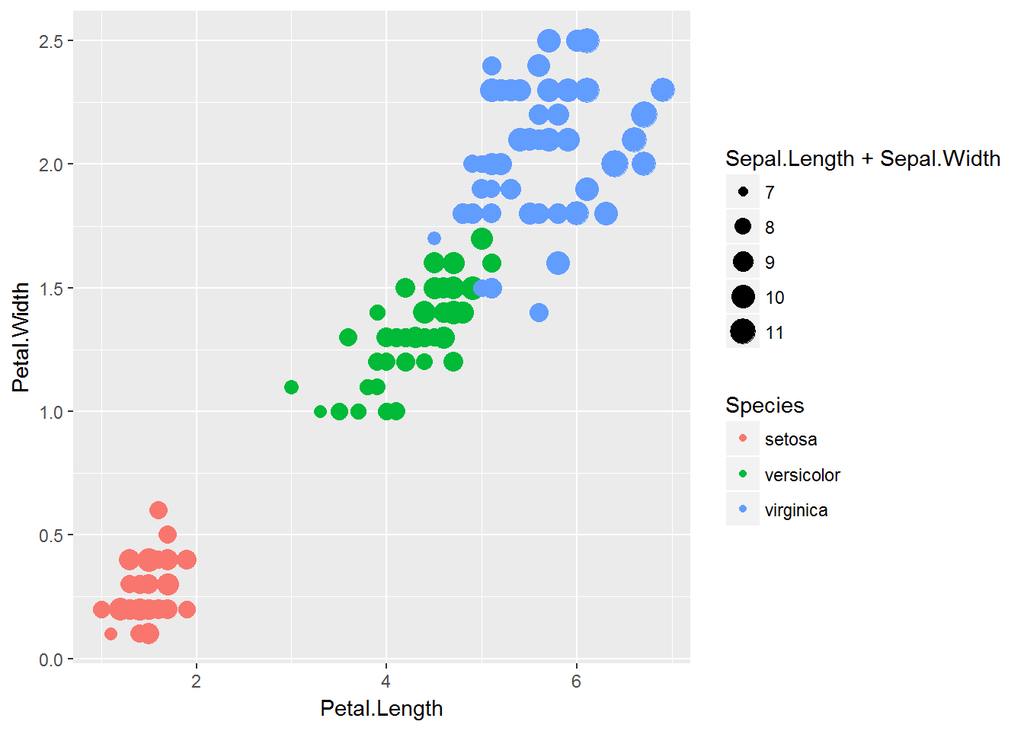

```r
qplot(Petal.Length,Petal.Width,data=iris,colour=Species,size=Sepal.Length+Sepal.Width)
```

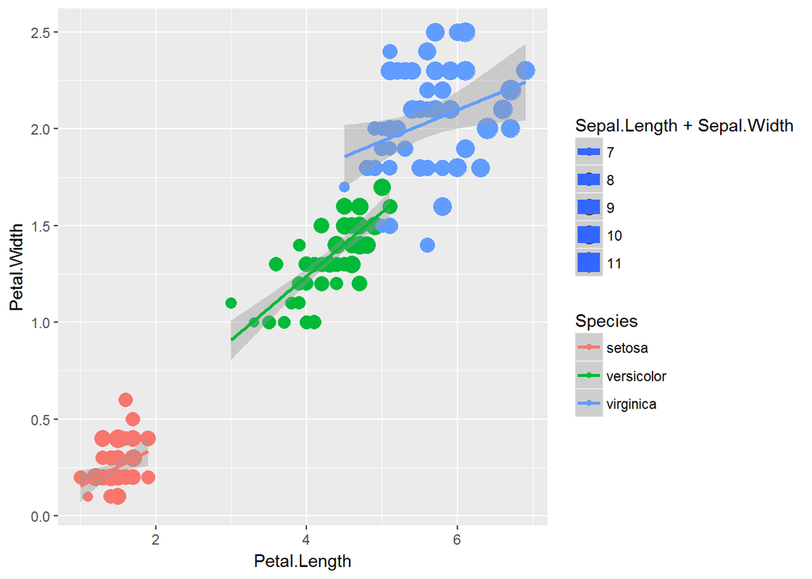

```r
qplot(Petal.Length,Petal.Width,data=iris,colour=Species,size=Sepal.Length+Sepal.Width)+geom_smooth(method = "lm")
```

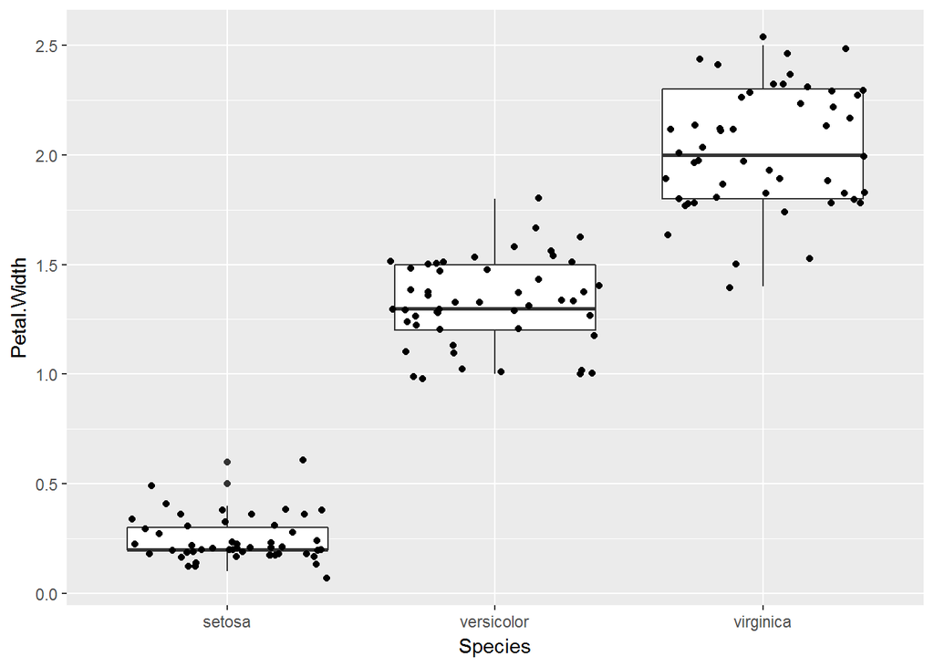

```r
qplot(Species,Petal.Width,data = iris,geom = c("boxplot","jitter"))
```

```r
tab <- read.table(file.choose(), header = T)
structure(tab)
```

```
##    index      age    height
## 1      1 2.065875 0.7791893
## 2      2 2.368409 0.9159676
## 3      3 2.539993 0.9053835
## 4      4 2.542080 0.9056614
## 5      5 2.549079 0.9389889
## 6      6 2.786688 0.9668474
## 7      7 2.911682 0.9643682
## 8      8 3.035627 0.9144594
## 9      9 3.114670 0.9393394
## 10    10 3.158239 0.9607497
## 11    11 3.327594 0.8983709
## 12    12 3.379316 0.9120974
## 13    13 3.412201 0.9423850
## 14    14 3.421582 0.9662458
```

[output cut: 36 more lines]

2- Charger le vecteur age dans une variable nommée x.

```r
x<-tab[,2]
```

3- Charger le vecteur height dans une variable nommée y.

```r
y<-tab[,3]
```

4- Donner la distribution de y en fonction de x (utiliser les fonctions plot et qplot).

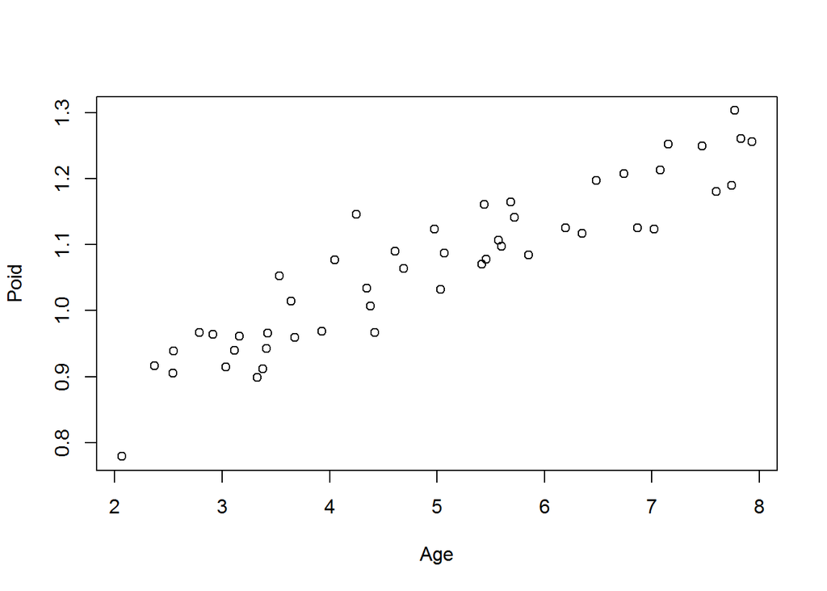

```r
m <- length(y)
plot(x,y,xlab="Age", ylab="Poid")
```

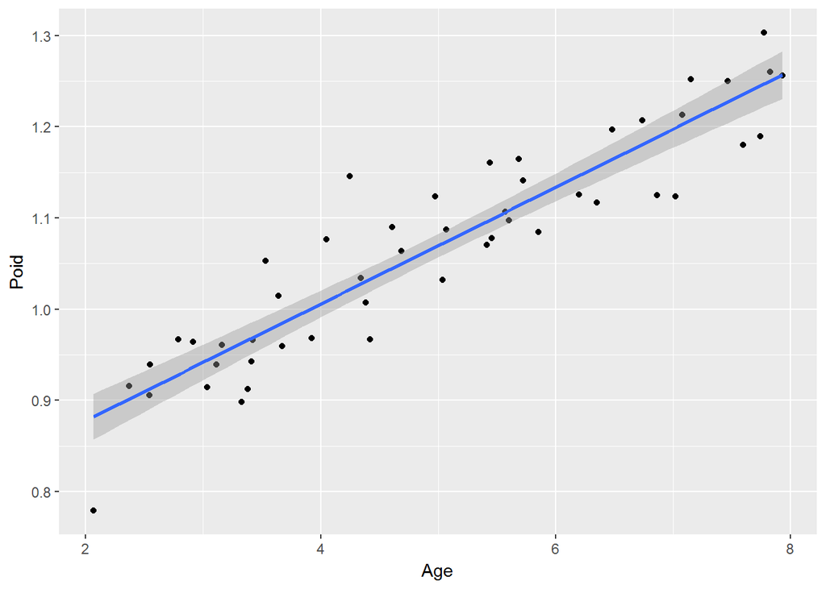

```r
require(ggplot2)
qplot(x,y,xlab="Age", ylab="Poid")+geom_smooth(method="lm")
```

5- On regardant le graphique. Peut-on dire qu’il y a une corrélation entre les deux variables. Justifiez.

```r
cor(x,y)
```

```
## [1] 0.926317
```

6- Prouvez d’une manière statistique (rigoureuse) que x et y sont soit corrélées soit non ?

```r
#reste
```

```r
m1<-lm(height ~ age, data=tab)
m1
```

```
##
## Call:
## lm(formula = height ~ age, data = tab)
##
## Coefficients:
## (Intercept)          age
##     0.75016      0.06388
```

8- Quelle est la valeur de l’erreur résiduelle.

```r
summary(m1)
```

```
##
## Call:
## lm(formula = height ~ age, data = tab)
##
## Residuals:
##       Min        1Q    Median        3Q       Max
## -0.102944 -0.028680  0.000225  0.027735  0.123947
##
## Coefficients:
##             Estimate Std. Error t value Pr(>|t|)
## (Intercept)  0.75016    0.01955   38.38   <2e-16 ***
## age          0.06388    0.00375   17.04   <2e-16 ***
## ---
## Signif. codes:  0 '***' 0.001 '**' 0.01 '*' 0.05 '.' 0.1 ' ' 1
##
## Residual standard error: 0.04535 on 48 degrees of freedom
## Multiple R-squared:  0.8581, Adjusted R-squared:  0.8551
## F-statistic: 290.2 on 1 and 48 DF,  p-value: < 2.2e-16
```

9- Donnez l’équation de la droite de régression.

**Y=0.06388X+0.75016**

10- Dessiner la droite de régression.

```r
#abline (m1, col="red")
```

11- Selon le modèle trouvé prédire les poids de 4 enfants ayant respectivement 3, 7, 9 et 12 ans.

```r
predict(m1, data.frame("age"=3))
```

```
##        1
## 0.941806
```

```r
predict(m1, data.frame("age"=7))
```

```
##        1
## 1.197331
```

```r
predict(m1, data.frame("age"=9))
```

```
##        1
## 1.325093
```

```r
predict(m1, data.frame("age"=12))
```

```
##        1
## 1.516737
```

12- Prédire la taille d’un enfant de 10 ans avec un intervalle de confiance de 95%.

```r
predict(m1, data.frame("age"=10), interval="prediction",level = 0.95)
```

```
##        fit      lwr      upr
## 1 1.388974 1.289251 1.488697
```

### Exercice 05

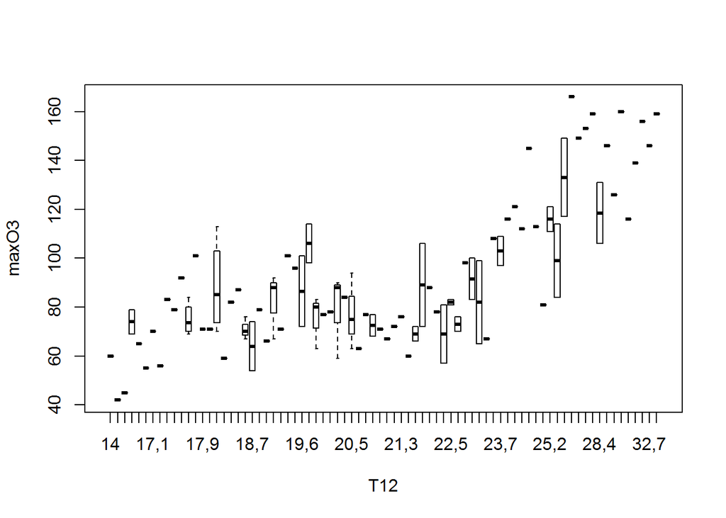

```r
ozone <- read.table(file.choose(), header = T)
plot(maxO3~T12,data=ozone)
```

Une régression linéaire simple semble-t-elle justifiée graphiquement ?

reponse : NON

```r
reg<-lm(maxO3~T12,data=ozone)
resume<-summary(reg)
resume
```

```
##
## Call:
## lm(formula = maxO3 ~ T12, data = ozone)
##
## Residuals:
##    Min     1Q Median     3Q    Max
## -20.00  -0.25   0.00   1.00  24.75
##
## Coefficients:
##               Estimate Std. Error t value Pr(>|t|)
## (Intercept)  6.000e+01  1.416e+01   4.237 0.000163 ***
## T1214,3     -1.800e+01  2.002e+01  -0.899 0.375032
## T1214,5     -1.500e+01  2.002e+01  -0.749 0.458962
## T1215,6      1.400e+01  1.734e+01   0.807 0.425107
## T1216,3      5.000e+00  2.002e+01   0.250 0.804327
## T1216,8     -5.000e+00  2.002e+01  -0.250 0.804327
## T1217,1      1.000e+01  2.002e+01   0.499 0.620724
## T1217,3     -4.000e+00  2.002e+01  -0.200 0.842863
## T1217,4      2.300e+01  2.002e+01   1.149 0.258743
## T1217,5      1.900e+01  2.002e+01   0.949 0.349402
## T1217,6      3.200e+01  1.734e+01   1.845 0.073726 .
## T1217,7      1.500e+01  1.583e+01   0.948 0.350062
## T1217,8      4.100e+01  2.002e+01   2.047 0.048400 *
## T1217,9      1.100e+01  2.002e+01   0.549 0.586373
## T1218        1.100e+01  2.002e+01   0.549 0.586373
## T1218,2      2.825e+01  1.583e+01   1.784 0.083270 .
## T1218,3     -1.000e+00  2.002e+01  -0.050 0.960464
## T1218,4      2.200e+01  2.002e+01   1.099 0.279641
## T1218,5      2.700e+01  2.002e+01   1.348 0.186463
## T1218,6      1.100e+01  1.635e+01   0.673 0.505633
## T1218,7      4.000e+00  1.734e+01   0.231 0.818964
## T1218,8      1.900e+01  2.002e+01   0.949 0.349402
## T1218,9      6.000e+00  2.002e+01   0.300 0.766283
## T1219,1      2.233e+01  1.635e+01   1.366 0.180922
## T1219,2      1.100e+01  2.002e+01   0.549 0.586373
## T1219,3      4.100e+01  2.002e+01   2.047 0.048400 *
## T1219,4      3.600e+01  2.002e+01   1.798 0.081097 .
## T1219,6      2.650e+01  1.734e+01   1.528 0.135739
## T1219,7      4.600e+01  1.734e+01   2.653 0.012052 *
## T1219,8      1.533e+01  1.635e+01   0.938 0.354953
```

[output cut: 39 more lines]

```
## T1228,4      5.850e+01  1.734e+01   3.373 0.001867 **
## T1228,6      8.600e+01  2.002e+01   4.295 0.000138 ***
## T1229,5      6.600e+01  2.002e+01   3.296 0.002301 **
## T1229,6      1.000e+02  2.002e+01   4.994 1.75e-05 ***
## T1229,8      5.600e+01  2.002e+01   2.797 0.008438 **
## T1230,1      7.900e+01  2.002e+01   3.945 0.000379 ***
## T1230,5      9.600e+01  2.002e+01   4.794 3.17e-05 ***
## T1232,7      8.600e+01  2.002e+01   4.295 0.000138 ***
## T1233,5      9.900e+01  2.002e+01   4.944 2.03e-05 ***
## ---
## Signif. codes:  0 '***' 0.001 '**' 0.01 '*' 0.05 '.' 0.1 ' ' 1
##
## Residual standard error: 14.16 on 34 degrees of freedom
## Multiple R-squared:  0.9227, Adjusted R-squared:  0.7477
## F-statistic: 5.271 on 77 and 34 DF,  p-value: 4.212e-07
```

Que représente les coefficients de la matrice coefficients ?

reponse : represente la concentration en ozone par rapport à la température à midi

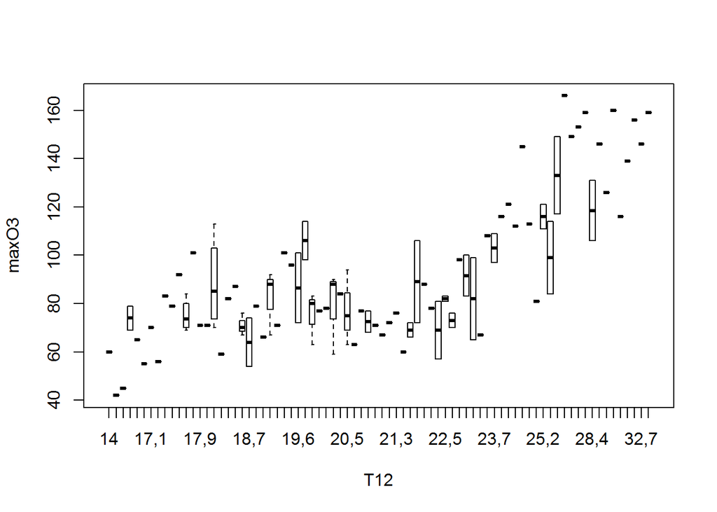

```r
plot(maxO3~T12,data=ozone)
```

```r
#T12=seq(min(ozone[,"T12"]),max(ozone[,"T12"]),length=100)
#grille<-data.frame(T12)
#ICdte<-predict(reg,new=grille,interval="confidence",level=0.95)
#matlines(grille$T12,cbind(ICdte),lty=c(1,2,2),col=1)

#res<-rstudent(reg)
#plot(res,pch=15,ylab=Résidus,ylim=c(-3,3))
#abline(h=c(-2,0,2),lty=c(2,1,2)
```

Que remarquez-vous ?

reponse :

```r
#plot(maxO3~T12,data=ozone)
#T12=seq(min(ozone[,"T12"]),max(ozone[,"T12"]),length=100)
#grille<-data.frame(T12)
#ICprev<-predict(reg,new=grille,interval="pred",level=0.95)
#matlines(grille$T12,cbind(ICprev),lty=c(1,2,2),col=1)
```

```r
seuil<-qt(0.975,df=reg$df.res)
beta0min<-coef(resume)[1,1]-seuil*coef(resume)[1,2]
beta0max<-coef(resume)[1,1]+seuil*coef(resume)[1,2]
beta1min<-coef(resume)[2,1]-seuil*coef(resume)[2,2]
beta1max<-coef(resume)[2,1]+seuil*coef(resume)[2,2]
```

reponse :

```r
#library(ellipse)
#plot(ellipse(reg,level=0.95),type="l",xlab="beta0",ylab="beta1")
#points(coef(reg)[1],coef(reg)[2],pch=3)
#lines(c(beta0min,beta0min,beta0max,beta0max,beta0min),c(beta1min,bet
#a1max,beta1max,beta1min,beta1min),lty=2)
#plot(ellipse(reg,level=0.95),type="l",xlab="beta0",ylab="beta1")
#points(coef(reg)[1],coef(reg)[2],pch=3)
#lines(c(beta0min,beta0min,beta0max,beta0max,beta0min),c(beta1min,bet
#a1max,beta1max,beta1min,beta1min),lty=2)
```